# 單因子變異數分析

Week 10｜Part 2・比較三組以上的平均

HT3001B 生物統計學與 R

2026-11-12

## 三組以上的平均，要怎麼比？

- 15 位受試者隨機分派到催眠、高動機、冥想三種情境，每組 5 人。每人回答 10 題受暗示性題目，分數越高代表越容易接受暗示。
- **先預測**。你預期哪一組的樣本平均會較高？哪兩組可能接近？

| 理論 | 對受暗示分數的預測 |
| --- | --- |
| 深度放鬆理論 | 催眠組與冥想組相近 |
| 強化動機理論 | 高動機組高於冥想組 |
| 變更意識狀態理論 | 催眠組高於冥想組與高動機組 |

研究問題是三種情境的**母體平均**是否全部相同。

[IMS 2e Ch. 22（比較多組平均數）](https://openintro-ims.netlify.app/inference-many-means)。催眠研究為課堂案例。

## 為什麼不直接做三次 t 檢定？

- 三組兩兩比較。哪兩次比較會用到同一個催眠組？
- 如果每次都用 $\alpha=.05$，做三次時至少碰巧錯一次的機率，會比做一次高嗎？
- 催眠對動機、催眠對冥想都會用到催眠組。
- 至少出現一次型一錯誤的機率稱為**整族錯誤率（familywise error rate）**。
- 若三個 $H_0$ 都成立且三次檢定彼此獨立，機率是 $1-(1-.05)^3\approx.14$。實際的三次成對比較會共用組別，.14 是獨立檢定的示意值。

[figure not shown]

這條曲線假定每次檢定的 H₀ 都成立，而且檢定彼此獨立。

[IMS 2e Ch. 22 開頭與 §22.2（多次比較的問題）](https://openintro-ims.netlify.app/inference-many-means)。圖中數值依本頁公式計算。自製圖。

## ANOVA 先問一個整體問題

如果只做一次檢定，你會用一句什麼話來寫三組的虛無假設？

- **單因子變異數分析（one-way analysis of variance, ANOVA）**用一次**整體檢定（omnibus test）**比較所有組別。

$$H_0:\mu_1=\mu_2=\mu_3$$

- $H_1$：至少有兩組母體平均不同。
- 「單因子」指一個分組變項，此處是情境。

[figure not shown]

每條線代表一組母體分布。比較曲線中心的位置。

[IMS 2e Ch. 22 開頭（ANOVA 的假設）](https://openintro-ims.netlify.app/inference-many-means)。自製示意圖。

## 哪一側的組別比較容易分辨？

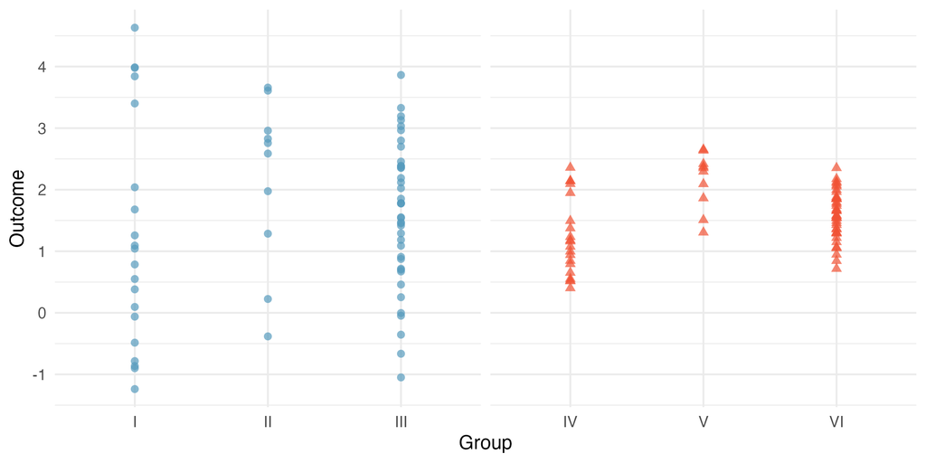

每個點是一筆觀察。把左側 I、II、III 和右側 IV、V、VI 分開看。

哪一側比較容易從分數辨認出一個位置特別高的組？你看的是哪些點？

右側的 V 組較容易辨認。右側各組的點比較集中，組平均的差距相對於組內散布比較明顯。

[IMS 2e Ch. 22 開頭](https://openintro-ims.netlify.app/inference-many-means)。課本原圖 22.1（CC BY-SA 3.0）。

## 催眠研究的 15 筆資料

[figure not shown]

每個點是一位受試者。橘線是各組平均，虛線是總平均。

從圖中找出三組平均和總平均。催眠組的 10 分，比它所在組的平均高幾分？

| 組別 | 五筆分數 | 平均 |
| --- | --- | --- |
| 催眠 | 8、9、10、6、7 | 8 |
| 動機 | 7、4、6、5、8 | 6 |
| 冥想 | 2、3、0、0、0 | 1 |

總平均 5 分。催眠組的 10 分比組平均高 2 分。

催眠研究為課堂案例。自製圖。

## 從總平均到個人分數，要走哪兩段？

[figure not shown]

每個點是一位受試者。橘線是各組平均，虛線是總平均。

在圖上找出總平均 5、催眠組平均 8 和個人分數 10。從 5 經過 8 到 10，兩段各差多少？

[figure not shown]

到總平均的距離 5，等於組平均到總平均的 3，加上分數到組平均的 2。

$10-5=(8-5)+(10-8)=3+2$。

同組若有人得 6 分，第二段的正負號會怎麼變？

第二段是 $6-8=-2$，所以 $6-5=3+(-2)=1$。

[IMS 2e §22.2.1（組間與組內的變異）](https://openintro-ims.netlify.app/inference-many-means)。催眠研究為課堂案例。自製圖。

## 總變異：每個分數離總平均多遠？

[figure not shown]

每個點是一位受試者。橘線是各組平均，虛線是總平均。

若每個分數都要和同一個總平均相比，從每個點應畫線到哪裡？

[figure not shown]

每條線是一個分數到總平均 5 的距離。

都連到總平均 5。偏差有正有負，先平方再加總，得到**總平方和**。整份資料的**平方和（sum of squares, SS）**是 $SS_{\text{total}}=158$。

[IMS 2e §22.2.1（SST）](https://openintro-ims.netlify.app/inference-many-means)。催眠研究為課堂案例。自製圖。

## 組間變異：如果每個人都剛好是組平均

[figure not shown]

每個點是一位受試者。橘線是各組平均，虛線是總平均。

把每個人的分數換成自己的組平均。每組的點會排在哪裡？接著要和哪一條線相比？

[figure not shown]

橘點是把每個人換成組平均後的位置。橘線是組平均到總平均的距離。

各組的點排在組平均，並與總平均 5 相比。每組都有 5 人，**組間平方和**是 $SS_B=5(3)^2+5(1)^2+5(-4)^2=130$。

[IMS 2e §22.2.1（SSG）](https://openintro-ims.netlify.app/inference-many-means)。催眠研究為課堂案例。自製圖。

## 組內變異：同一組的人為什麼不一樣？

[figure not shown]

每個點是一位受試者。橘線是各組平均，虛線是總平均。

只想量同一組內的散布時，每個分數要跟哪個平均比？

[figure not shown]

橘線是各組平均。每條灰線是一個分數到自己組平均的距離。

每個分數連到自己組的平均。三組各自平方後加總為 10、10、8。**組內平方和**是 $SS_W=10+10+8=28$。

[IMS 2e §22.2.1（SSE）](https://openintro-ims.netlify.app/inference-many-means)。催眠研究為課堂案例。自製圖。

## 兩段偏差平方後，還能加回去嗎？

催眠組有一位受試者得 10 分，總偏差是 $10-5=3+2$。平方後等於 $3^2+2^2$ 嗎？

平方展開用 $(a+b)^2=a^2+2ab+b^2$。

$$\begin{aligned}
(10-5)^2 &=[(8-5)+(10-8)]^2\\
&=3^2+2\times3\times2+2^2\\
&=9+12+4=25
\end{aligned}$$

中間的 $2\times3\times2=12$ 是這一筆的**交叉項**。

五人的分數各減去組平均 8，得到 $0,1,2,-2,-1$。組平均減總平均都是 $8-5=3$，所以五人的交叉項加總為

$$2\times3\times(0+1+2-2-1)=0.$$

每組的個人偏差加總為 0，因為組平均乘以人數正好等於組內分數總和。乘上同一個係數後，該組的交叉項加總仍是 0。

[figure not shown]

橘色是組間平方和，灰色是組內平方和。

整份資料的平方和 $SS_T=SS_B+SS_W$。  
代入本例，$158=130+28$。

[IMS 2e §22.2.1（SST = SSG + SSE）](https://openintro-ims.netlify.app/inference-many-means)。催眠研究為課堂案例。自製圖。

## 把三組的樣本平均移到 5，會改變什麼？

[figure not shown]

每個點是一位受試者。橘線是各組平均，虛線是總平均。

如果把每一組的點整組上下平移，讓三組的樣本平均都變成 5，組間與組內平方和會各自怎麼變？

平移後，每個 ● 仍代表一位受試者。

| 平移後分數 | 催眠 | 動機 | 冥想 |
| --- | --- | --- | --- |
| 7 | ● | ● | ● |
| 6 | ● | ● | ● |
| **5** | ● | ● |  |
| 4 | ● | ● | ●●● |
| 3 | ● | ● |  |

組間平方和變成 0，組內仍是 28。這是平移同一份樣本的結果。若母體平均相同而重新抽樣，各組樣本平均仍會浮動。

依催眠研究資料計算的假想對照。左圖為自製點圖，右表顯示平移後的資料。

## 兩個平方和怎麼放到同一尺度？

| 來源 | 平方和 | 自由度 |
| --- | --- | --- |
| 組間 | 130 | 2 |
| 組內 | 28 | 12 |

這兩個平方和用到不同數量的資訊。要把它們放到可比較的尺度，各要除以哪個數？

- 各自除以該列的自由度，得到**均方（mean square, MS）**。

$$MS_B=\frac{SS_B}{k-1},\qquad MS_W=\frac{SS_W}{N-k}$$

- $k$ 是組數，$N$ 是總人數。$MS_W$ 是組內變異數的合併估計。各組同樣大時，它等於各組樣本變異數的平均。

[IMS 2e §22.2.1（MSG 與 MSE）](https://openintro-ims.netlify.app/inference-many-means)。課本把 $MS_B$ 記為 MSG，$MS_W$ 記為 MSE。合併變異數見 Rosner 8e §8.4。

## 組間均方比組內均方大很多，F 會怎麼變？

[figure not shown]

每個點是一位受試者。橘線是各組平均，虛線是總平均。

如果組間均方與組內均方差不多，兩者的比值會接近 0 還是 1？如果組間均方大很多呢？

$$F=\frac{MS_B}{MS_W}$$

在 $H_0$ 與模型條件成立時，兩個均方估計同一個母體變異數。估計值相近時，$F$ 接近 1。組間均方相對越大，$F$ 越大，所以看 **F 分布（F distribution）**的右尾。

[IMS 2e §22.3.1（F 統計量與 F 檢定）](https://openintro-ims.netlify.app/inference-many-means)。自製圖。

## 催眠案例｜假設與統計量

催眠研究有三組不同的人，每人量一次。請用「母體平均受暗示分數」寫出虛無假設，再選一個能一次比較三組的統計量。

- **形成假設**。$H_0:\mu_{\text{催眠}}=\mu_{\text{動機}}=\mu_{\text{冥想}}$。$H_1$：至少有兩組母體平均不同。事先設定 $\alpha=.05$。
- **選定統計量**。三組平均做整體比較，用單因子 ANOVA 的 $F$。
- **選定參考分布**。在 $H_0$ 和模型條件成立時，使用自由度 2 與 12 的 F 分布。

[IMS 2e §22.3.1（F 檢定）](https://openintro-ims.netlify.app/inference-many-means)。催眠研究為課堂案例。

## 使用 F 分布前，要查哪些條件？

[figure not shown]

每個點是一位受試者。橘線是各組平均，虛線是總平均。

獨立性要看點圖，還是要查受試者怎麼分組與量測？每組 5 人，從這張圖能判斷母體的形狀嗎？

- **觀察值獨立**。查收集方式，留意同一人量多次、配對或成群收集。
- **各組近似常態**。分組看偏斜與極端值。冥想組 5 人中有 3 個 0，單靠這些點很難判斷母體形狀。
- **各組變異數相近**。分組比較散布。組別人數不相同時更要留意。

[IMS 2e §22.3.4（ANOVA 的條件）](https://openintro-ims.netlify.app/inference-many-means)。 催眠研究點圖為自製圖。

## 練習 1｜填完 ANOVA 表

把催眠研究的 ANOVA 表填完。先算兩個均方，保留原分數計算 $F$。

| 來源 | 平方和 | 自由度 | 均方 | $F$ |
| --- | --- | --- | --- | --- |
| 組間 | 130 | 2 | ？ | ？ |
| 組內 | 28 | 12 | ？ |  |
| 總和 | 158 | 14 |  |  |

- $MS_B=130/2=65$，$MS_W=28/12\approx2.33$。
- $F=65/(28/12)\approx27.86$。均方留到最後才四捨五入。

[figure not shown]

每個點是一位受試者。橘線是各組平均，虛線是總平均。

[IMS 2e §22.3.3（ANOVA 表）](https://openintro-ims.netlify.app/inference-many-means)。催眠研究為課堂案例。 自製圖。

## 催眠案例｜查分布、作決策、寫結論

[figure not shown]

虛線標示臨界值 3.89。觀察到的 F = 27.86 在圖的範圍外。

$p$ 值要從 3.89 還是從 27.86 開始往右算？在 $\alpha=.05$ 下，你會怎麼回答研究問題？

- $p$ 值從觀察到的 27.86 往右算。條件成立時，$p\approx.000031$，拒絕 $H_0$。
- 資料支持**至少兩組母體平均受暗示分數不同**。8、6、1 是樣本平均。要找出哪些組別不同，需要另外比較。

[IMS 2e §22.3.2（F 檢定的決策與解讀）](https://openintro-ims.netlify.app/inference-many-means)。催眠研究為課堂案例。自製圖。

## 讀一張 ANOVA 表

課本把 429 位大聯盟球員依守備位置分成外野、內野、捕手，分析上壘率。

| 來源 | 自由度 | 平方和 | 均方 | $F$ | $p$ |
| --- | --- | --- | --- | --- | --- |
| 守備位置 | 2 | 0.0161 | 0.0080 | 5.08 | .0066 |
| 殘差 | 426 | 0.6740 | 0.0016 |  |  |

哪一列的均方是組內均方？用一句話解讀 $p=.0066$。

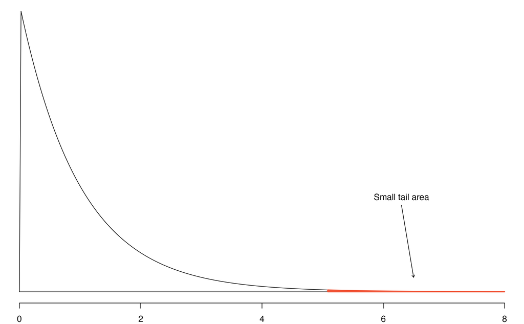

自由度 2 與 426 的 F 分布。右尾的紅色小面積是 p 值。

組內均方在殘差列。以 $\alpha=.05$ 判斷，資料支持這些守備位置的母體平均上壘率不全相同。

[IMS 2e §22.3.2–22.3.3（讀 ANOVA 表）](https://openintro-ims.netlify.app/inference-many-means)。課本表 22.5 與原圖 22.7（CC BY-SA 3.0）。

## 練習 2｜該用哪一種方法？

先看有幾組、每人量幾次，再選方法。

1. 兩組不同的病人各服用一種藥，比較平均收縮壓。
2. 四組不同的病人各服用一種劑量，比較平均收縮壓。
3. 同一批病人在服藥前、服藥一週後、一個月後各量一次收縮壓。
1. 可用獨立樣本 t 檢定。等變異數模型下，合併法雙尾 t 與經典單因子 ANOVA 決策相同。
2. 條件成立時，可用單因子 ANOVA。
3. 同一人的三筆資料彼此相關，需要能處理重複量測的方法。

前往 Slido · 閱讀補充例題

自編整合練習。對照 [IMS 2e Ch. 20–22](https://openintro-ims.netlify.app/statistical-inference)。

## 同樣的拆法適用於每個人

以催眠組得 6 分的人為例。從總平均 5 到組平均 8，再走到個人分數 6。哪一段是負值？

$$\underbrace{X_{ij}-\bar X_G}_{\text{分數到總平均}}
=\underbrace{\bar X_j-\bar X_G}_{\text{組平均到總平均}}
+\underbrace{X_{ij}-\bar X_j}_{\text{分數到組平均}}$$

| 組別 | 分數 | 到總平均 | 組平均到總平均 | 分數到組平均 |
| --- | --- | --- | --- | --- |
| 催眠組 | 10 | 5 | 3 | 2 |
| 催眠組 | 6 | 1 | 3 | −2 |
| 動機組 | 7 | 2 | 1 | 1 |
| 動機組 | 4 | −1 | 1 | −2 |
| 冥想組 | 3 | −2 | −4 | 2 |
| 冥想組 | 0 | −5 | −4 | −1 |

同一組的人，「組平均到總平均」那一段都一樣。「分數到組平均」那一段每個人不同。

[IMS 2e §22.2.1（組間與組內的變異）](https://openintro-ims.netlify.app/inference-many-means)。催眠研究為課堂案例。

## 打亂考卷標籤後，怎麼找 p 值？

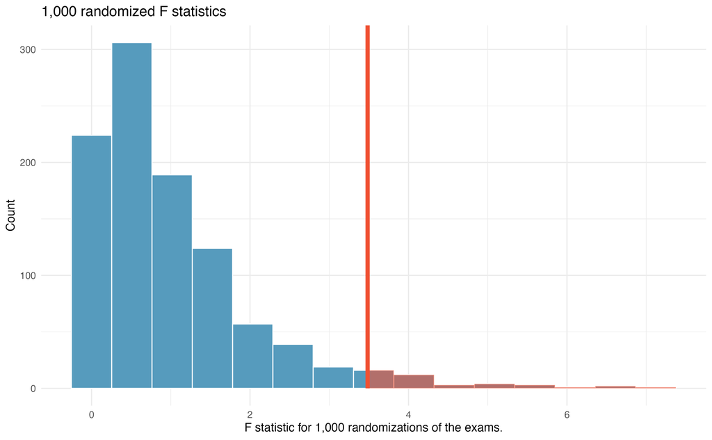

重排 1,000 次得到的 F。紅線是觀察到的 3.48，比較紅線兩側的長條。

課本比較 A、B、C 三種考卷的難度。假設在 $H_0$ 下考卷標籤可以互換。把標籤打亂後重算 $F$，為什麼要數紅線右側？

紅線是觀察到的 $F=3.48$。重排 1,000 次，有 3.6% 的 $F$ 大於等於 3.48，因此 $p\approx.036$。

[IMS 2e §22.2.2–22.2.3（隨機化檢定）](https://openintro-ims.netlify.app/inference-many-means)。課本原圖 22.6（CC BY-SA 3.0）。

## 組間平方和占總變異多少？

催眠研究的組間平方和是 130，組內平方和是 28，總平方和是 158。要量組間占總變異的比例，應該用哪兩個數相除？

[figure not shown]

η² 就是組間平方和佔總平方和的比例。

**效果量 $\eta^2$（eta squared）**為 $130/158\approx.82$。這是樣本中的比例，小樣本的估計容易偏高。

[Lakens, Ch. 6（§6.6–6.7，可解釋的變異與偏差校正）](https://lakens.github.io/statistical_inferences/06-effectsize.html)。催眠研究為課堂案例。自製圖。

## 練習 3｜社會增強物研究

32 人隨機分到四組，每組 8 人。每人談 10 分鐘的生活哲學，實驗者依組別回應樂觀陳述，並記錄每人說了幾次。

|  | 呃呃 | 控制 | 微笑 | 嗯哼 |
| --- | --- | --- | --- | --- |
| 平均 | 6 | 12 | 16 | 18 |
| 變異數 | 8 | 8 | 10.86 | 12 |

請算出 $MS_B$、$MS_W$ 與 $F$。自由度 3 與 28、$\alpha=.05$ 的臨界值是 2.95。

[figure not shown]

橘點是組平均，灰線表示 ±1 個標準差，虛線是總平均 13。

1. **算均方。** $SS_B=8\,[(-7)^2+(-1)^2+3^2+5^2]=672$，$MS_B=224$，$MS_W=(8+8+10.86+12)/4\approx9.715$。
2. **比較 $F$。** $F=224/9.715\approx23.06>2.95$。拒絕 $H_0$，四組的平均樂觀陳述次數不全相同。

社會增強物研究為課堂案例。依表列摘要計算。自製圖。

## Slido｜單因子 ANOVA 概念題

三題單選，每題 45 秒。題目在 Slido 上作答，由課堂啟動。

[**開啟 Slido 作答頁**](https://app.sli.do/event/4RKuNjEES1smpx47Wt9DxL) · 活動代碼 **4269651**

[figure not shown]

第十週 Slido 作答入口 QR code，活動代碼 4269651。

[第十週 Slido](https://app.sli.do/event/4RKuNjEES1smpx47Wt9DxL)；題目對應本講次的整族錯誤率、F 統計量與結論範圍。